# Data handling and curation - from raw to clean data

Aud Halbritter (adapted from Matt Grainger)

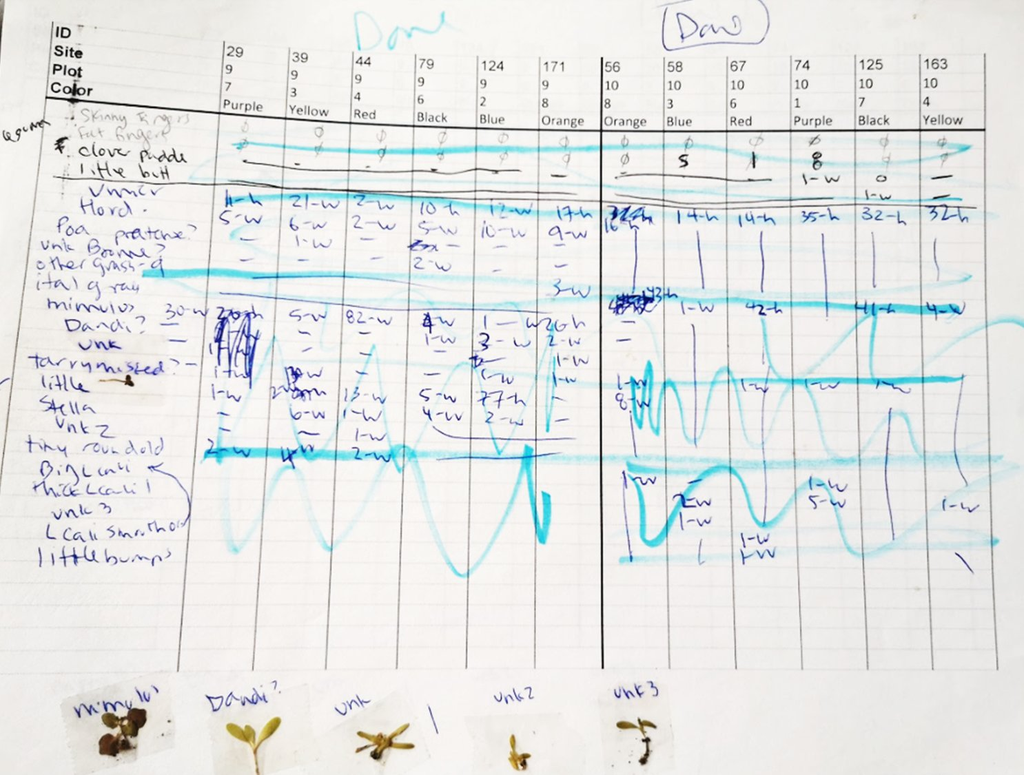

## Data cycle

[figure not shown]

## Data handling and curation is time consuming

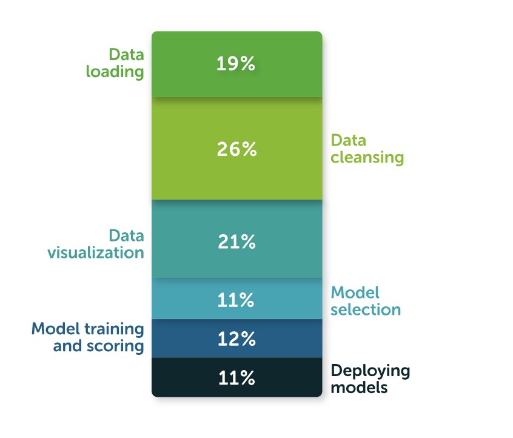

## Data cleaning vs Data wrangling

*Data cleaning* is the process of removing incorrect, duplicate, typos, or otherwise erroneous data from a dataset

*Data wrangling* changing the format to make it more useful for your analysis

### Import data with read_delim

See [Import data](https://biostats-r.github.io/biostats/workingInR/005_Importing_Data_in_R.html) BioST@TS tutorial

```r
read_delim(file = "data/plant_community_2024.csv")
```

### Data cleaning with the Palmer penguins dataset

**Exercise**

Run the following commands to install the palmerpenguins package.

```r
#install.packages("palmerpenguins")
library(palmerpenguins)
head(penguins_raw)
```

```
# A tibble: 6 × 17
  studyName `Sample Number` Species          Region Island Stage `Individual ID`
  <chr>               <dbl> <chr>            <chr>  <chr>  <chr> <chr>
1 PAL0708                 1 Adelie Penguin … Anvers Torge… Adul… N1A1
2 PAL0708                 2 Adelie Penguin … Anvers Torge… Adul… N1A2
3 PAL0708                 3 Adelie Penguin … Anvers Torge… Adul… N2A1
4 PAL0708                 4 Adelie Penguin … Anvers Torge… Adul… N2A2
5 PAL0708                 5 Adelie Penguin … Anvers Torge… Adul… N3A1
6 PAL0708                 6 Adelie Penguin … Anvers Torge… Adul… N3A2
# ℹ 10 more variables: `Clutch Completion` <chr>, `Date Egg` <date>,
#   `Culmen Length (mm)` <dbl>, `Culmen Depth (mm)` <dbl>,
#   `Flipper Length (mm)` <dbl>, `Body Mass (g)` <dbl>, Sex <chr>,
#   `Delta 15 N (o/oo)` <dbl>, `Delta 13 C (o/oo)` <dbl>, Comments <chr>
```

### Clean names with janitor

```r
penguins_raw |>
  names()
```

```
 [1] "studyName"           "Sample Number"       "Species"
 [4] "Region"              "Island"              "Stage"
 [7] "Individual ID"       "Clutch Completion"   "Date Egg"
[10] "Culmen Length (mm)"  "Culmen Depth (mm)"   "Flipper Length (mm)"
[13] "Body Mass (g)"       "Sex"                 "Delta 15 N (o/oo)"
[16] "Delta 13 C (o/oo)"   "Comments"
```

### Clean names with janitor

```r
penguins_raw |>
  names()
```

```
 [1] "studyName"           "Sample Number"       "Species"
 [4] "Region"              "Island"              "Stage"
 [7] "Individual ID"       "Clutch Completion"   "Date Egg"
[10] "Culmen Length (mm)"  "Culmen Depth (mm)"   "Flipper Length (mm)"
[13] "Body Mass (g)"       "Sex"                 "Delta 15 N (o/oo)"
[16] "Delta 13 C (o/oo)"   "Comments"
```

```r
penguins_clean <- penguins_raw |>
  janitor::clean_names(case = "snake")

penguins_clean |>
  names()
```

```
 [1] "study_name"        "sample_number"     "species"
 [4] "region"            "island"            "stage"
 [7] "individual_id"     "clutch_completion" "date_egg"
[10] "culmen_length_mm"  "culmen_depth_mm"   "flipper_length_mm"
[13] "body_mass_g"       "sex"               "delta_15_n_o_oo"
[16] "delta_13_c_o_oo"   "comments"
```

### Get a glimps wiht dplyr

```r
penguins_clean |>
  dplyr::glimpse()
```

```
Rows: 344
Columns: 17
$ study_name        <chr> "PAL0708", "PAL0708", "PAL0708", "PAL0708", "PAL0708…
$ sample_number     <dbl> 1, 2, 3, 4, 5, 6, 7, 8, 9, 10, 11, 12, 13, 14, 15, 1…
$ species           <chr> "Adelie Penguin (Pygoscelis adeliae)", "Adelie Pengu…
$ region            <chr> "Anvers", "Anvers", "Anvers", "Anvers", "Anvers", "A…
$ island            <chr> "Torgersen", "Torgersen", "Torgersen", "Torgersen", …
$ stage             <chr> "Adult, 1 Egg Stage", "Adult, 1 Egg Stage", "Adult, …
$ individual_id     <chr> "N1A1", "N1A2", "N2A1", "N2A2", "N3A1", "N3A2", "N4A…
$ clutch_completion <chr> "Yes", "Yes", "Yes", "Yes", "Yes", "Yes", "No", "No"…
$ date_egg          <date> 2007-11-11, 2007-11-11, 2007-11-16, 2007-11-16, 200…
$ culmen_length_mm  <dbl> 39.1, 39.5, 40.3, NA, 36.7, 39.3, 38.9, 39.2, 34.1, …
$ culmen_depth_mm   <dbl> 18.7, 17.4, 18.0, NA, 19.3, 20.6, 17.8, 19.6, 18.1, …
$ flipper_length_mm <dbl> 181, 186, 195, NA, 193, 190, 181, 195, 193, 190, 186…
$ body_mass_g       <dbl> 3750, 3800, 3250, NA, 3450, 3650, 3625, 4675, 3475, …
$ sex               <chr> "MALE", "FEMALE", "FEMALE", NA, "FEMALE", "MALE", "F…
$ delta_15_n_o_oo   <dbl> NA, 8.94956, 8.36821, NA, 8.76651, 8.66496, 9.18718,…
$ delta_13_c_o_oo   <dbl> NA, -24.69454, -25.33302, NA, -25.32426, -25.29805, …
$ comments          <chr> "Not enough blood for isotopes.", NA, NA, "Adult not…
```

### Skim your data with skimr

```r
out <- penguins_clean |>
  skimr::skim()

out
```

Data summary

| Name | penguins_clean |
| --- | --- |
| Number of rows | 344 |
| Number of columns | 17 |
| _______________________ |  |
| Column type frequency: |  |
| character | 9 |
| Date | 1 |
| numeric | 7 |
| ________________________ |  |
| Group variables | None |

**Variable type: character**

| skim_variable | n_missing | complete_rate | min | max | empty | n_unique | whitespace |
| --- | --- | --- | --- | --- | --- | --- | --- |
| study_name | 0 | 1.00 | 7 | 7 | 0 | 3 | 0 |
| species | 0 | 1.00 | 33 | 41 | 0 | 3 | 0 |
| region | 0 | 1.00 | 6 | 6 | 0 | 1 | 0 |
| island | 0 | 1.00 | 5 | 9 | 0 | 3 | 0 |
| stage | 0 | 1.00 | 18 | 18 | 0 | 1 | 0 |
| individual_id | 0 | 1.00 | 4 | 6 | 0 | 190 | 0 |
| clutch_completion | 0 | 1.00 | 2 | 3 | 0 | 2 | 0 |
| sex | 11 | 0.97 | 4 | 6 | 0 | 2 | 0 |
| comments | 290 | 0.16 | 18 | 68 | 0 | 10 | 0 |

**Variable type: Date**

| skim_variable | n_missing | complete_rate | min | max | median | n_unique |
| --- | --- | --- | --- | --- | --- | --- |
| date_egg | 0 | 1 | 2007-11-09 | 2009-12-01 | 2008-11-09 | 50 |

**Variable type: numeric**

| skim_variable | n_missing | complete_rate | mean | sd | p0 | p25 | p50 | p75 | p100 | hist |
| --- | --- | --- | --- | --- | --- | --- | --- | --- | --- | --- |
| sample_number | 0 | 1.00 | 63.15 | 40.43 | 1.00 | 29.00 | 58.00 | 95.25 | 152.00 | ▇▇▆▅▃ |
| culmen_length_mm | 2 | 0.99 | 43.92 | 5.46 | 32.10 | 39.23 | 44.45 | 48.50 | 59.60 | ▃▇▇▆▁ |
| culmen_depth_mm | 2 | 0.99 | 17.15 | 1.97 | 13.10 | 15.60 | 17.30 | 18.70 | 21.50 | ▅▅▇▇▂ |
| flipper_length_mm | 2 | 0.99 | 200.92 | 14.06 | 172.00 | 190.00 | 197.00 | 213.00 | 231.00 | ▂▇▃▅▂ |
| body_mass_g | 2 | 0.99 | 4201.75 | 801.95 | 2700.00 | 3550.00 | 4050.00 | 4750.00 | 6300.00 | ▃▇▆▃▂ |
| delta_15_n_o_oo | 14 | 0.96 | 8.73 | 0.55 | 7.63 | 8.30 | 8.65 | 9.17 | 10.03 | ▃▇▆▅▂ |
| delta_13_c_o_oo | 13 | 0.96 | -25.69 | 0.79 | -27.02 | -26.32 | -25.83 | -25.06 | -23.79 | ▆▇▅▅▂ |

**Exercise**

Run the following functions:

`clean_names()`

`glimpse()`

`skimr::skim()`

### Data validation

```r
library(validate)

rules <- validator(culm = culmen_length_mm >= 0,
                   body = body_mass_g > 3000,
                   species = is.character(species),
                   sex = sex %in% c("FEMALES", "MALE"))
```

### Data validation

```r
out   <- confront(penguins_clean, rules)
summary(out)
```

```
     name items passes fails nNA error warning                     expression
1    culm   344    342     0   2 FALSE   FALSE culmen_length_mm - 0 >= -1e-08
2    body   344    331    11   2 FALSE   FALSE             body_mass_g > 3000
3 species     1      1     0   0 FALSE   FALSE          is.character(species)
4     sex   344    168   165  11 FALSE   FALSE sex %vin% c("FEMALES", "MALE")
```

### Data validation

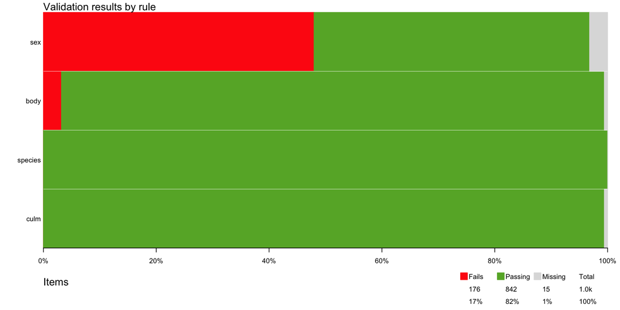

```r
plot(out)
```

## Rules for data cleaning

- Deposit and back-up raw data files
- Do not manually manipulate the raw data files
- Clean data using code
- Check the cleaning code

### Keep track of changes with tidylog

```r
library(tidylog)
```

```r
dat <- penguins_clean |>
  tidylog::select(study_name, species, island, individual_id, body_mass_g) |>
  tidylog::filter(species %in% c("Adelie Penguin (Pygoscelis adeliae)"))
```

```
select: dropped 12 variables (sample_number, region, stage, clutch_completion, date_egg, …)
filter: removed 192 rows (56%), 152 rows remaining
```

### Remove duplicates with dplyr

```
# A tibble: 4 × 2
  Day       Person
  <chr>     <chr>
1 Monday    Becks
2 Tuesday   Amy
3 Wednesday Matt
4 Wednesday Matt
```

### Remove duplicates with dplyr

```r
duplicate_data |>
  tidylog::distinct()
```

```
distinct: removed one row (25%), 3 rows remaining
```

```
# A tibble: 3 × 2
  Day       Person
  <chr>     <chr>
1 Monday    Becks
2 Tuesday   Amy
3 Wednesday Matt
```

## Missing data

Missing data is often a problem, e.g. for running a model. Typically as ecologists we sweep missing data under the carpet by using a “complete case” approach to data analysis.

[figure not shown]

If you have ever written some code like this:

```r
newdf <- na.omit(penguins_clean)

newdf <- penguins_clean[complete.cases(penguins_clean), ]

newdf <- penguins_clean |>
  tidyr::drop_na()
```

you are removing missing data (NAs) from your dataset.

### Why is this a problem?

By throwing away potentially useful data (only including those rows without a NA in them) you reduce the information you are working with, reduce statistical power and introduce selection bias (invalidating any assumption of randomisation).

### Vizualise missing data with naniar

```r
penguins_messy |>
  naniar::vis_miss()
```

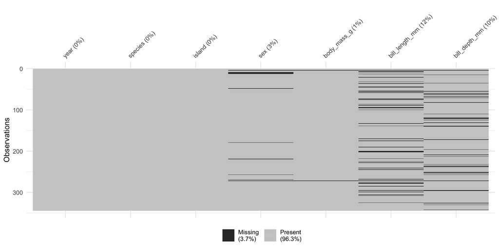

### Different types of missingness

Data can be missing random or systematically.

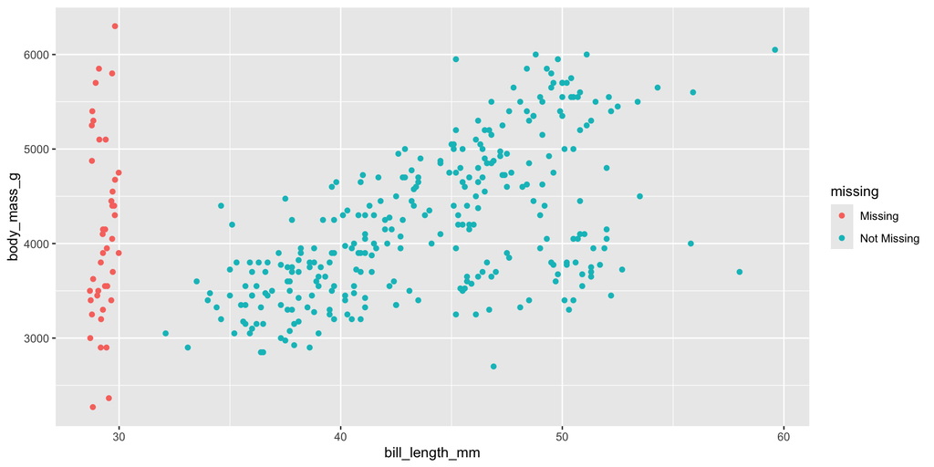

```r
library(naniar)
penguins_messy |>
  ggplot(aes(x = bill_length_mm, y = body_mass_g)) +
  geom_miss_point()
```

### Data wrangling with dplyr

[figure not shown]

### Data wrangling with dplyr

[figure not shown]

### Data wrangling with tidyr

[figure not shown]

**Exercise**

Use the penguins dataset to:

- Select the columns species, island and body_mass_g
- Filter for the species Adelie and the island Biscoe and Dream
- Convert the penguin body mass from gram to kilogram
- Calculate the mean bill length and standard error for each penguin species
- Make a wide dataset showing the body mass for each penguin species in a separate column. And turn it back to a long dataframe.

Import the *messy_data.RDS* data file and clean it.

## Reproducible workflows

[figure not shown]

## Reproducible workflows

[figure not shown]